# Assignment 1

Arshia Mahmoodi

## 1. Data set selection and Download

### Selected dataset GSE135511

```r
if (! requireNamespace("BiocManager", quietly = TRUE)) {
    install.packages("BiocManager")
}
if (! requireNamespace("GEOquery", quietly = TRUE)) {
    BiocManager::install("GEOquery")
}
if (!requireNamespace("GEOmetadb", quietly = TRUE)){
    BiocManager::install("GEOmetadb")
}
if (!requireNamespace("edgeR", quietly = TRUE)){
    BiocManager::install("edgeR")
}
```

```r
library(GEOquery)

gse_name <- "GSE135511_RAW.tar"

if (!file.exists(gse_name)){
  gse <- getGEO("GSE135511", GSEMatrix = FALSE)
}

current_gpl <- names(GPLList(gse))[1]
current_gpl_info <- Meta(getGEO(current_gpl))
```

This data set is particularly interesting because not only does it document the pathological changes observed in grey matter in multiple sclerosis with augmented meningeal inflammation, but also demonstrates the actual pathways associated with this inflammatory response. This can be applied to genes involved in tumour signalling, which are are differentially regulated in multiple scleroris cases compared to the control.

**Platform title:** Illumina HumanRef-8 v3.0 expression beadchip

**Submission date** May 21 2008

**Last update date:** Mar 20 2017

**Organisms:** Homo sapiens

**Number of GEO datasets that use this techology:** 227

**Number of GEO samples that use this technology:** 7092

## 2. Overview and Mapping

```r
library(knitr)

sfiles = getGEOSuppFiles('GSE135511')

fnames = rownames(sfiles)

# Second supplementary file containing non-normalized data
supp = read.delim(fnames[2],header=TRUE,
                check.names = FALSE)
#head(supp)
kable(supp[1:10,1:5], format = "html")
```

| ID_REF | Control_A05-149 | Control_A05-149 : Detection Pval | Control_A05-58 | Control_A05-58 : Detection Pval |
| --- | --- | --- | --- | --- |
| ILMN_1802380 | 9.983321 | 0.0000000 | 10.066356 | 0.0000000 |
| ILMN_1792389 | 9.351906 | 0.0000000 | 9.074273 | 0.0000000 |
| ILMN_2375156 | 6.128371 | 0.1400602 | 5.849127 | 0.1641566 |
| ILMN_1697642 | 8.752439 | 0.0000000 | 8.450157 | 0.0000000 |
| ILMN_1681845 | 8.491746 | 0.0000000 | 8.160882 | 0.0000000 |
| ILMN_1690979 | 6.376297 | 0.0256024 | 6.251915 | 0.0195783 |
| ILMN_1811114 | 6.301253 | 0.0436747 | 6.838438 | 0.0030120 |
| ILMN_1660729 | 6.002863 | 0.4021084 | 5.741170 | 0.3433735 |
| ILMN_2129572 | 6.644665 | 0.0090361 | 6.553935 | 0.0075301 |
| ILMN_1705659 | 6.008120 | 0.3855422 | 5.533683 | 0.8704819 |

Dimensions of the data:

```r
dim(supp)
```

```
## [1] 22303   101
```

## 3. Mapping

We are observing 50 different motor-cortex tissue samples, 10 of which are non neurological control samples, derived from post-mortem multiple sclerosis brains.

Across these samples, 22303 rows of gene expression recorded and their respective value and p-value documented. Hence, the study has very good coverage of the data.

## 4. Data Visualization before Normalization

Boxplot of our data values

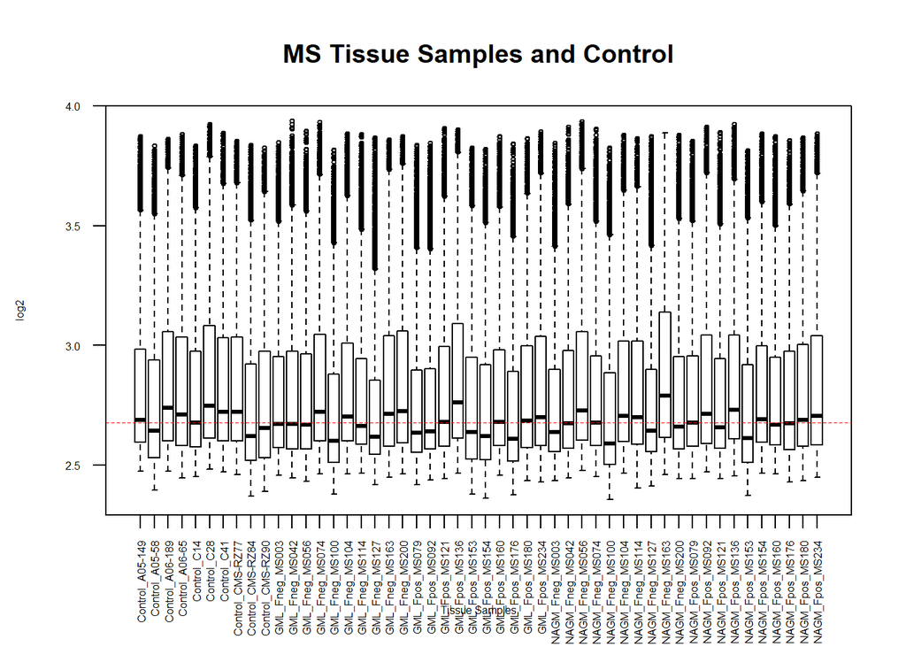

```r
Values <- seq(2, 101, 2)
P_Values <- seq(3, 101, 2)

supp_P_values <- supp[2:22303,P_Values]
supp_values <- supp[2:22303,Values]

data2plot <- log2(supp_values)
boxplot(data2plot, xlab = "Tissue Samples", ylab = "log2",
        las = 2, cex = 0.5, cex.lab = 0.5,
        cex.axis = 0.5, main = "MS Tissue Samples and Control")

abline(h = median(apply(data2plot, 2, median)), col = "red", lwd = 0.6, lty = "dashed")
```

Density Plot of the data P-Value distribution

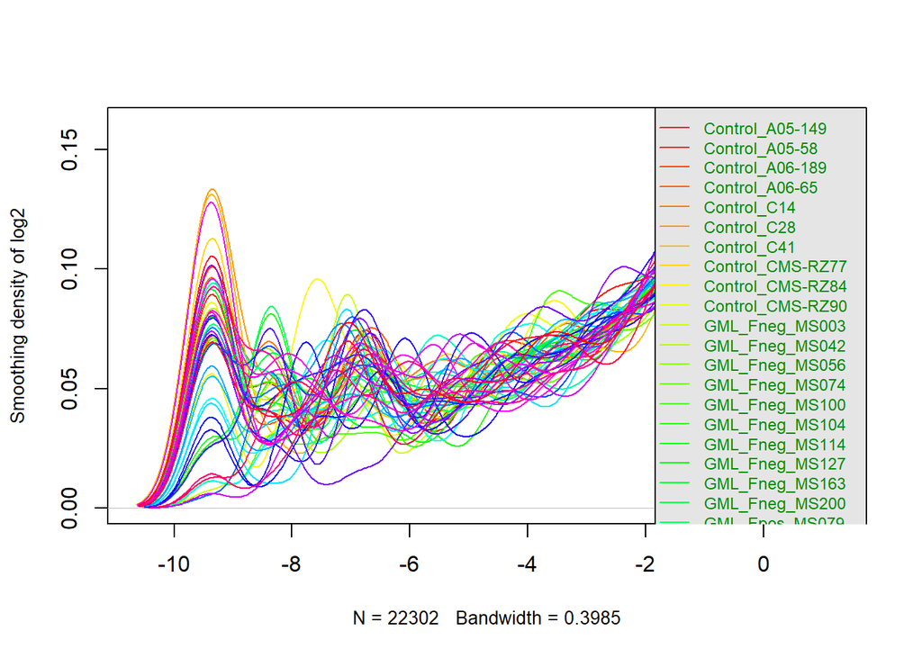

```r
counts_density <- apply(log2(supp_P_values), 2, density)
  #calculate the limits across all the samples
    xlim <- 0; ylim <- 0
    for (i in 1:length(counts_density)) {
      xlim <- range(c(xlim, counts_density[[i]]$x));
      ylim <- range(c(ylim, counts_density[[i]]$y))
    }
    cols <- rainbow(length(counts_density))
    ltys <- rep(1, length(counts_density))
    #plot the first density plot to initialize the plot
    plot(counts_density[[1]], xlim=xlim, ylim=ylim, type="n",
         ylab="Smoothing density of log2", main="", cex.lab = 0.85)
    #plot each line
    for (i in 1:length(counts_density)) lines(counts_density[[i]], col=cols[i], lty=ltys[i])
    #create legend
    legend("topright", colnames(data2plot),
           col=cols, lty=ltys, cex=0.75,
           border ="blue",  text.col = "green4",
           merge = TRUE, bg = "gray90")
```

## 5. Normalizing the data

```r
library(edgeR)
```

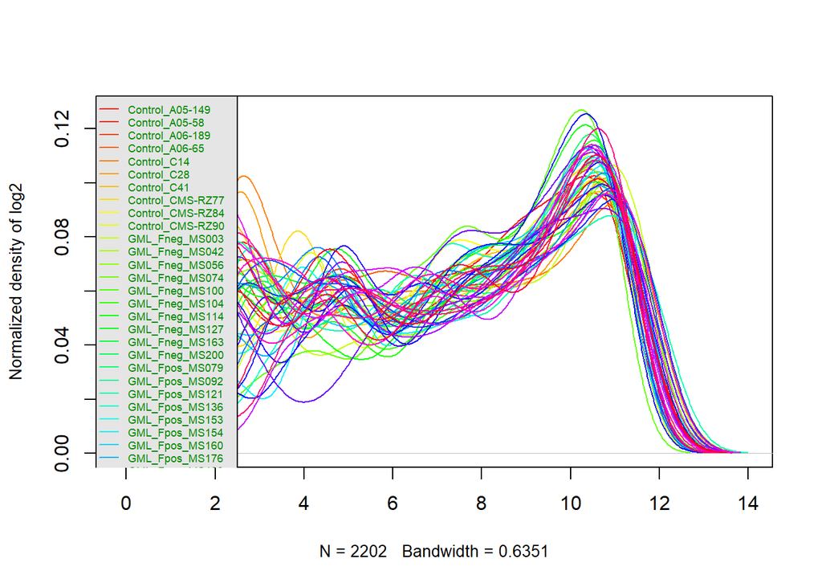

```r
filtered_data_matrix <- as.matrix(supp[2:2203,P_Values])
#head(filtered_data_matrix)
rownames(filtered_data_matrix) <- supp[2:2203,1]
d = DGEList(counts=filtered_data_matrix, group=supp[1,P_Values])
d = calcNormFactors(d)
normalized_counts <- cpm(d)
normalized_density <- apply(log2(normalized_counts[,2:50]), 2,density)

xlim <- 0; ylim <- 0
for (i in 1:length(normalized_density)) {
  xlim <- range(c(xlim, normalized_density[[i]]$x));
  ylim <- range(c(ylim, normalized_density[[i]]$y))
}
cols <- rainbow(length(normalized_density))
ltys <- rep(1, length(normalized_density))
#plot the first density plot to initialize the plot
plot(normalized_density[[1]], xlim=xlim, ylim=ylim, type="n",
     ylab="Normalized density of log2", main="", cex.lab =
       0.85)
#plot each line
for (i in 1:length(normalized_density)) lines(normalized_density[[i]],
                                          col=cols[i], lty=ltys[i])
#create legend
legend("topleft",colnames(data2plot),
       col=cols, lty=ltys, cex=0.55,
       border ="blue", text.col = "green4",
       merge = TRUE, bg = "gray90")
```

One thing we could consider is filtering values by a selected P-value threshhold specific to our experiment i,e P = 0.05 to remove non-significant results.

Normalizing and plotting the Box-Plot of our values:

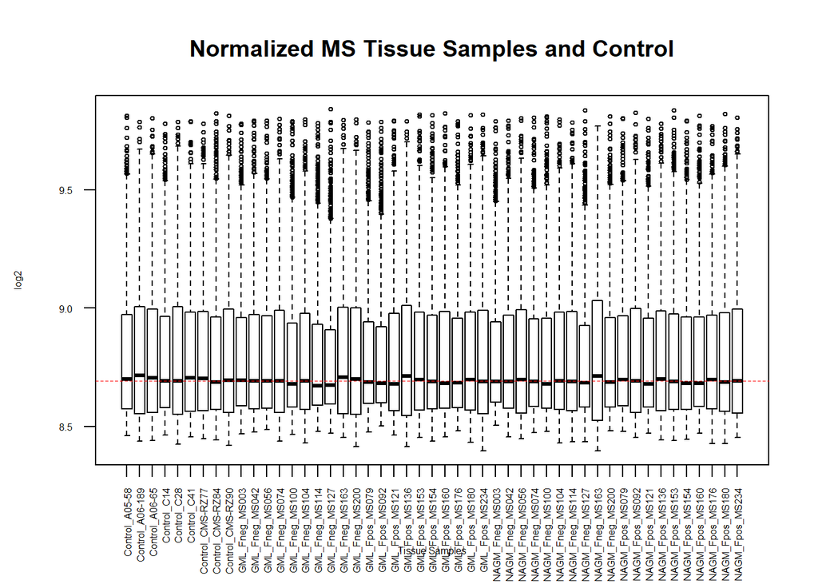

```r
filtered_data_matrix <- as.matrix(supp[2:2203,Values])
#head(filtered_data_matrix)
rownames(filtered_data_matrix) <- supp[2:2203,1]
d = DGEList(counts=filtered_data_matrix, group=supp[1,P_Values])
d = calcNormFactors(d)
normalized_counts <- cpm(d)
normalized_density <- apply(log2(normalized_counts[,2:50]), 2,density)

data2plot <- log2(normalized_counts[,2:50])
boxplot(data2plot, xlab = "Tissue Samples", ylab = "log2",
        las = 2, cex = 0.5, cex.lab = 0.5,
        cex.axis = 0.5, main = "Normalized MS Tissue Samples and Control")

abline(h = median(apply(data2plot, 2, median)), col = "red", lwd = 0.6, lty = "dashed")
```

## References

1. Magliozzi R, Howell OW, Durrenberger P, Aricò E et al. Meningeal inflammation changes the balance of TNF signalling in cortical grey matter in multiple sclerosis. J Neuroinflammation 2019 Dec 7;16(1):259. PMID: 31810488

Note: R code for this report was written following lecture notes in BCB420